# Exercise 1

2021-12-28

# Introduction to Bayesian t-test

The purpose of this exercise is to become familiar with using a Bayesian method to approximate the results of a Student’s t-test.

# Birthweight data analysis based on smoking status

## Data import

```r
bwBySmoke <- data.frame(
    `Birth weight` = c(
        3.18, 2.74, 2.9, 3.27, 3.65, 3.42, 3.23, 2.86, 3.6, 3.65, 3.69, 3.53, 2.38, 2.34, 3.99, 3.89, 3.6, 3.73, 3.31, 3.7, 4.08, 3.61, 3.83, 3.41, 4.13, 3.36, 3.54, 3.51, 2.71
        )
    , `Smoking habit` = c(
        'Heavy smokers', 'Heavy smokers', 'Heavy smokers', 'Heavy smokers', 'Heavy smokers', 'Heavy smokers', 'Heavy smokers', 'Heavy smokers', 'Heavy smokers', 'Heavy smokers', 'Heavy smokers', 'Heavy smokers', 'Heavy smokers', 'Heavy smokers', 'Non-smokers', 'Non-smokers', 'Non-smokers', 'Non-smokers', 'Non-smokers', 'Non-smokers', 'Non-smokers', 'Non-smokers', 'Non-smokers', 'Non-smokers', 'Non-smokers', 'Non-smokers', 'Non-smokers', 'Non-smokers', 'Non-smokers'
        )
    )
```

## Format structure

```r
library('tidyverse')

set.seed(03892)
bwBySmokeWide <-
  cbind(
    bwBySmoke %>%
      filter(Smoking.habit == 'Heavy smokers') %>%
      select(Birth.weight) %>%
      rename('Heavy smokers' = Birth.weight),
    bwBySmoke %>%
      filter(Smoking.habit == 'Non-smokers') %>%
      select(Birth.weight) %>%
      rename('Non-smokers' = Birth.weight) %>%
      slice_sample(n = nrow(.) - 1)
)

bwBySmokeWide
```

```
##    Heavy smokers Non-smokers
## 1           3.18        3.99
## 2           2.74        3.31
## 3           2.90        3.41
## 4           3.27        3.60
## 5           3.65        4.13
## 6           3.42        4.08
## 7           3.23        3.83
## 8           2.86        3.36
## 9           3.60        3.89
## 10          3.65        3.54
## 11          3.69        3.70
## 12          3.53        2.71
## 13          2.38        3.61
## 14          2.34        3.73
```

## Running the frequentist t-test

```r
freqTtestRes <- t.test(bwBySmokeWide$`Heavy smokers`, bwBySmokeWide$`Non-smokers`)

freqTtestRes
```

```
##
##  Welch Two Sample t-test
##
## data:  bwBySmokeWide$`Heavy smokers` and bwBySmokeWide$`Non-smokers`
## t = -2.9067, df = 24.802, p-value = 0.007583
## alternative hypothesis: true difference in means is not equal to 0
## 95 percent confidence interval:
##  -0.7872847 -0.1341438
## sample estimates:
## mean of x mean of y
##  3.174286  3.635000
```

## Running the Bayesian t-test

Notice you may get error and need to install JAGS (or rjags) from [here](https://sourceforge.net/projects/mcmc-jags/files/JAGS/4.x/).

```r
# install.packages('BEST')
library('BEST')
bayesTtestRes <- BESTmcmc(bwBySmokeWide$`Heavy smokers`, bwBySmokeWide$`Non-smokers`)

bayesTtestRes
```

```
## MCMC fit results for BEST analysis:
## 100002 simulations saved.
##           mean       sd  median  HDIlo   HDIup  Rhat n.eff
## mu1     3.1872  0.14282  3.1879 2.8990  3.4637 1.000 57266
## mu2     3.6474  0.10943  3.6484 3.4275  3.8636 1.000 57207
## nu     33.1614 29.26485 24.4085 1.5081 91.3215 1.002 18899
## sigma1  0.4989  0.12084  0.4801 0.2973  0.7451 1.000 32102
## sigma2  0.3829  0.09443  0.3695 0.2193  0.5759 1.000 33412
##
## 'HDIlo' and 'HDIup' are the limits of a 95% HDI credible interval.
## 'Rhat' is the potential scale reduction factor (at convergence, Rhat=1).
## 'n.eff' is a crude measure of effective sample size.
```

Viewing more output from Bayesian t-test results

```r
summary(bayesTtestRes)
```

```
##             mean median   mode HDI%  HDIlo  HDIup compVal %>compVal
## mu1        3.187  3.188  3.181   95  2.899  3.464
## mu2        3.647  3.648  3.654   95  3.428  3.864
## muDiff    -0.460 -0.460 -0.475   95 -0.820 -0.111       0     0.702
## sigma1     0.499  0.480  0.453   95  0.297  0.745
## sigma2     0.383  0.369  0.349   95  0.219  0.576
## sigmaDiff  0.116  0.109  0.102   95 -0.178  0.428       0    79.714
## nu        33.161 24.409  9.375   95  1.508 91.321
## log10nu    1.363  1.388  1.427   95  0.586  2.065
## effSz     -1.054 -1.050 -1.062   95 -1.917 -0.215       0     0.702
```

## Plotting Bayesian t-test results

Basic plot

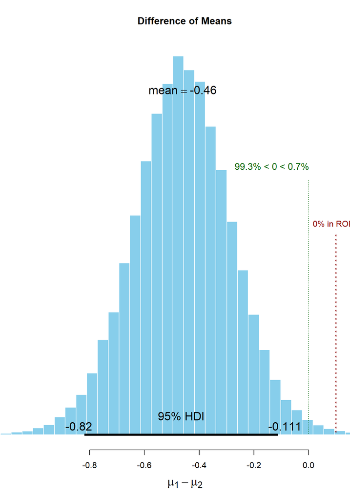

```r
plot(bayesTtestRes, compVal = 0, ROPE = c(0.1, 0.1))
```

Posterior probability distributions for each population.

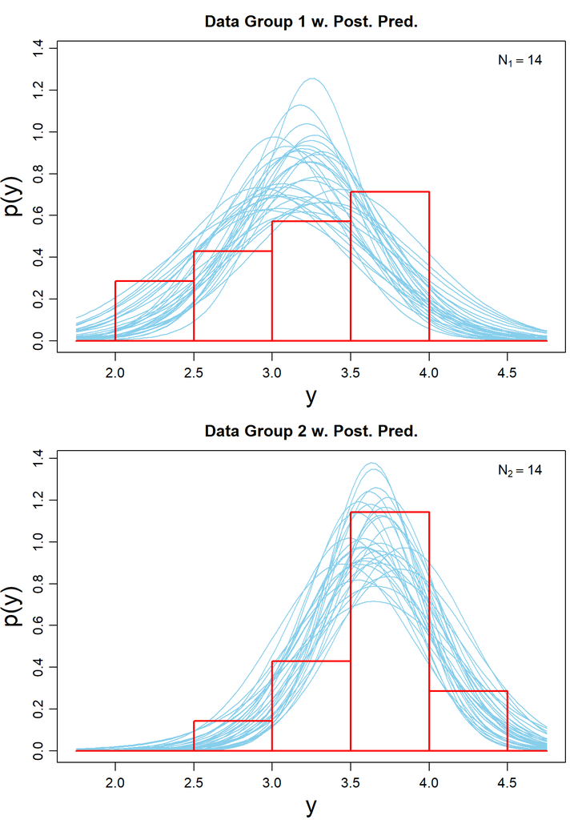

```r
plotPostPred(bayesTtestRes)
```

Plot all results from the Bayesian t-test.

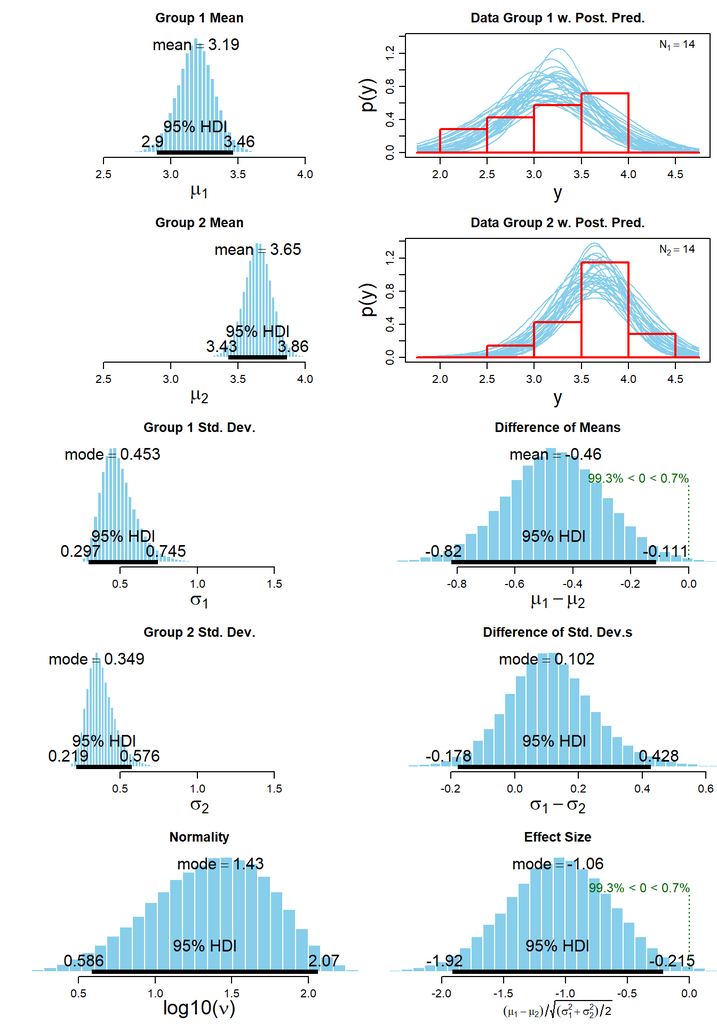

```r
plotAll(bayesTtestRes)
```

# Bayesian t-test on a different dataset

Use `Arrests` dataset to see if difference in age between those released with summons or not after being caught with a small amount of marijuana in Toronto from 1997 to 2002.

```r
arrests <-
  Arrests %>%
  select(released, age)

arrests
```

```
##      released age
## 1         Yes  21
## 2          No  17
## 3         Yes  24
## 4          No  46
## 5         Yes  27
## 6         Yes  16
## 7         Yes  40
## 8         Yes  34
## 9         Yes  23
## 10        Yes  30
## 11        Yes  18
## 12        Yes  18
## 13        Yes  17
## 14        Yes  42
```

[output cut: 5212 more lines]

```r
arrestsWide <-
  cbind(
    arrests %>%
      filter(released == 'Yes') %>%
      select(age) %>%
      rename('Released' = age) %>%
      slice_sample(n = 892),
    arrests %>%
      filter(released == 'No') %>%
      select(age) %>%
      rename('Not released' = age)
  )

arrestBayesTtestRes <- BESTmcmc(arrestsWide$Released, arrestsWide$`Not released`)

summary(arrestBayesTtestRes)
```

```
##             mean median   mode HDI%  HDIlo   HDIup compVal %>compVal
## mu1       21.134 21.126 21.107   95 20.598 21.6891
## mu2       22.032 22.025 22.001   95 21.441 22.6340
## muDiff    -0.897 -0.898 -0.919   95 -1.560 -0.2502       0      0.40
## sigma1     5.061  5.052  5.051   95  4.470  5.6597
## sigma2     5.748  5.740  5.733   95  5.168  6.3318
## sigmaDiff -0.687 -0.687 -0.695   95 -1.251 -0.1228       0      0.82
## nu         2.471  2.443  2.387   95  1.978  3.0174
## log10nu    0.390  0.388  0.380   95  0.303  0.4847
## effSz     -0.166 -0.166 -0.165   95 -0.289 -0.0456       0      0.40
```

Plots for the arrest data.

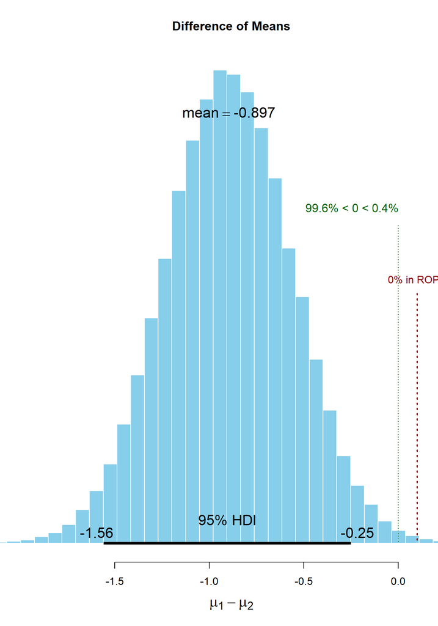

```r
plot(arrestBayesTtestRes, compVal = 0, ROPE = c(0.1, 0.1))
```

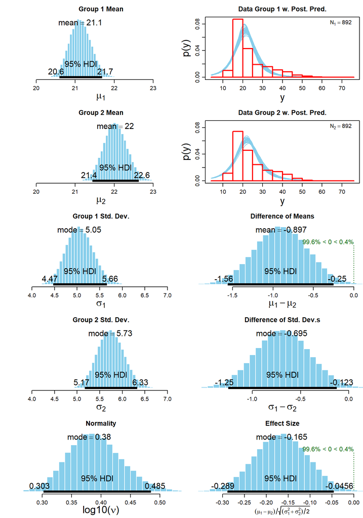

```r
plotAll(arrestBayesTtestRes)
```

Comparing to frequentist t-test.

```r
freqArrestsTtestRes <- t.test(arrestsWide$Released, arrestsWide$`Not released`)

freqArrestsTtestRes
```

```
##
##  Welch Two Sample t-test
##
## data:  arrestsWide$Released and arrestsWide$`Not released`
## t = -1.4842, df = 1781.8, p-value = 0.1379
## alternative hypothesis: true difference in means is not equal to 0
## 95 percent confidence interval:
##  -1.4184003  0.1964272
## sample estimates:
## mean of x mean of y
##  24.02466  24.63565
```

# Reflections

- Many of the outputs from the Bayesian analysis are not adequately explained in the course material.
- The Bayesian method is slow.
- The Bayesian method requires equal sample sizes, apparently, as indicated by the first step that required dropping an extra sample.
- It is unclear if there are ways to do paired / unpaired alternatives with the Bayesian method, or how to extend the Bayesian method to other more-complex models beyond a simple comparison of means in a t-test.
- The whole point of Bayesian methods is to start with a prior and update it, but the course material does not specify how to specify the baseline prior.
- The `BEST` package seems to run many simulations, perhaps by taking different subsets of the provided data? The course material did not specify how to set parameters for these simulations, such as iterations, sample size, etc.
- Using the `BEST` package with knitting a markdown file is odd, as it seems to restart the R session several times as evidenced by the log in the console when knitting these files.